# Part II - Ford GoBike System Duration Analysis

## by Emem Brownson

## Investigation Overview

The dataset includes information about individual rides made in a bike-sharing system covering the greater San Francisco Bay area. It has 183412 rows and 16 columns. Some wrangling process was needed to tidy the dataset for exploration. After tidying the dataset, I was left with 174952 rows and 19 columns which is saved as a .csv file called `goBike_clean.csv` (This dataset is what I used for the analysis). it has variables (columns) like `start_time(hr)`, `start_day`, `start_month`, `duration_sec` , `user_type`, `member_gender`, `age` etc.

## Dataset Overview

For the explanatory analysis/presentation, I will polish and visualized some of the analysis done in the exploratory analysis section which are:

- How long does the average trip take and on which day?
- On which day(s) and at what time were most trip taken?
- Which user took the longest trip on average and at what time of the day

## How long does the average trip take and on which day?

The longest trips on average happened on weekends, Saturdays and Sundays. It took about 800 to 850 seconds on average.

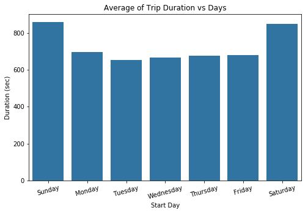

## On which day(s) and at what time were most trip taken?

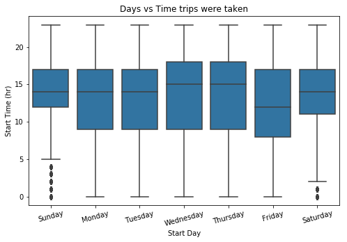

## Which user took the longest trip on average and at what time of the day

The longest trip was taken by a customer at the hour of 3 for about 5000 seconds.

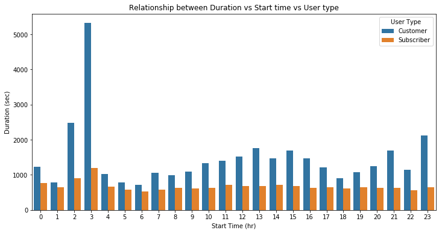